# Biomechanical features of orthopedic patients

# Correlation between models

We are interested in correlation because uncorrelated models do better when they are assembled than correlated presentations.

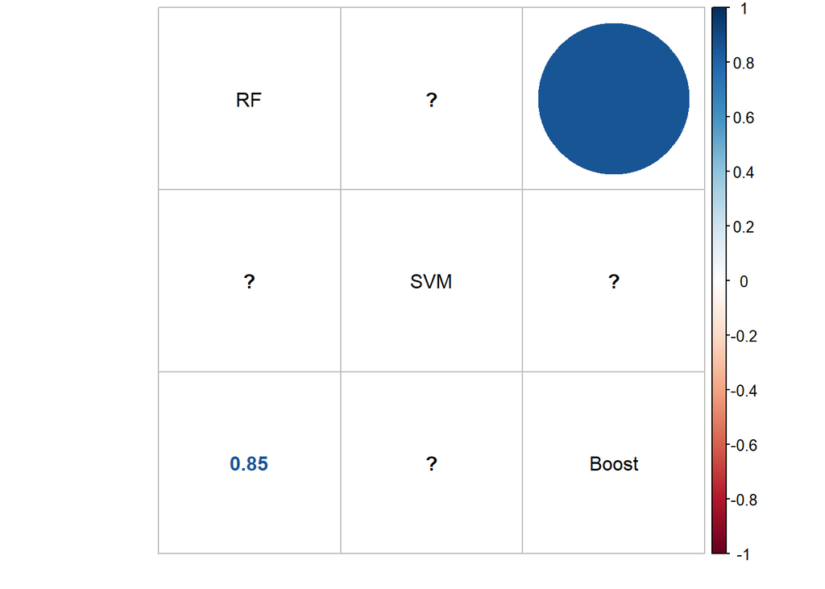

```r
#adding model predictions to test dataframe
testClean$RF <- as.numeric(solution_rf)-1
testClean$SVM <- as.numeric(solution_svm)-1
testClean$Boost <- as.numeric(solution_boost)-1

#compose correlations plot
corrplot.mixed(cor(testClean[, c('RF', 'SVM', 'Boost')]), tl.col="black")
```

We only observe a correlation, and a very strong correlation between RF and GBM, this is probably not surprising because these two algorithms are of very similar nature but on the other hand the SVM is very different algorithm of these two of or can be the lack of ability to provide the degree of correlation between the two previous models. We will now move to the majority vote, let us note

If 0 or 1 model predicts ‘Normal’, the overall prediction will be ‘Abnormal’

If 2 or 3 models predict ‘Normal’, the overall prediction will be ‘Normal’

```r
testClean$Sum <- testClean$RF + testClean$SVM + testClean$Boost
testClean$Majority <- ifelse(testClean$Sum<=1, 0,1)
```

# KNN Model Analysis

```r
caret_knn <- train(class~., data=dat, method='knn', trControl=trainControl(method="cv", number=5),tuneLength = 20)
caret_knn
```

```
## k-Nearest Neighbors
##
## 310 samples
##   6 predictor
##   2 classes: '0', '1'
##
## No pre-processing
## Resampling: Cross-Validated (5 fold)
## Summary of sample sizes: 248, 248, 248, 248, 248
## Resampling results across tuning parameters:
##
##   k   Accuracy   Kappa
##    5  0.8451613  0.6478670
##    7  0.8451613  0.6491898
##    9  0.8516129  0.6683433
##   11  0.8419355  0.6506181
##   13  0.8516129  0.6699149
##   15  0.8322581  0.6280133
##   17  0.8419355  0.6502643
##   19  0.8419355  0.6487686
##   21  0.8548387  0.6744509
##   23  0.8548387  0.6781268
##   25  0.8548387  0.6781268
##   27  0.8451613  0.6575559
##   29  0.8483871  0.6665305
##   31  0.8354839  0.6422849
##   33  0.8322581  0.6349675
##   35  0.8258065  0.6243601
##   37  0.8258065  0.6238018
##   39  0.8225806  0.6200497
##   41  0.8161290  0.6070226
##   43  0.8161290  0.6095299
##
## Accuracy was used to select the optimal model using the largest value.
## The final value used for the model was k = 25.
```

```r
#train
caret_knn <- train(class~., data=trainClean, method='knn', trControl=trainControl(method="cv", number=5),tuneLength = 20)
caret_knn
```

```
## k-Nearest Neighbors
##
## 205 samples
##   6 predictor
##   2 classes: '0', '1'
##
## No pre-processing
## Resampling: Cross-Validated (5 fold)
## Summary of sample sizes: 164, 164, 165, 163, 164
## Resampling results across tuning parameters:
##
##   k   Accuracy   Kappa
##    5  0.8687398  0.7111145
##    7  0.8539895  0.6843666
##    9  0.8492218  0.6742264
##   11  0.8345877  0.6471420
##   13  0.8348258  0.6552973
##   15  0.8250697  0.6341978
##   17  0.8297154  0.6504472
##   19  0.8298316  0.6512623
##   21  0.8347096  0.6622626
##   23  0.8347096  0.6622626
##   25  0.8201916  0.6342302
##   27  0.8250697  0.6433236
##   29  0.8250697  0.6433236
##   31  0.8201916  0.6331091
##   33  0.8201916  0.6328806
##   35  0.8250697  0.6438809
##   37  0.8250697  0.6438809
##   39  0.8201916  0.6342302
##   41  0.8055517  0.6061465
##   43  0.8005517  0.5941161
##
## Accuracy was used to select the optimal model using the largest value.
## The final value used for the model was k = 5.
```

# Conclusion

We analyze the Normal and Abnormal patient for different six biomechanical different biomechanicla desease.Found that 210 people are Abnormal and 100 people are normal.We have noticed that degree spondylolisthesis is the most important of the variables to explain the normal and abnormal of the patients.we analyze with decision tree ,boxplot.Also found the relationship between all the six different variables.There is correlation between degree spondylolisthesis and other variable.Also Noticed that high correlation between sacral_slope and pelvic_incidence. Also analyze the different algorithm like RandomForest,Support Vector Machine (SVM) model,Gradient Boosting Machine (GBM) modeland KNN model.